# 1. Dataset and Task

## 1.1

**Dataset Introduction** - Water quality is a critical issue for public health and environmental safety. Contaminated water can lead to numerous health hazards, including disease outbreaks and long-term exposure to toxic substances. Assessing water safety based on the presence of chemical and biological contaminants is essential to prevent health risks. The dataset includes 7999 samples and 21 features, each representing different chemical components or biological contaminants in the water. The dataset is designed for a binary classification task, where the goal is to predict whether a water sample is safe or unsafe based on the concentrations of various chemical and biological elements.

**Source:** This is an imaginary data of water quality hosted on Kaggle. Link: https://www.kaggle.com/datasets/mssmartypants/water-quality

**Dataset Size:** 7999 samples and 21 features.

**Features:** The dataset contains 21 features, each representing the concentration levels (in mg/L) of various chemicals, heavy metals, or biological contaminants:

- aluminium: Dangerous if greater than 2.8 mg/L.
- ammonia: Dangerous if greater than 32.5 mg/L.
- arsenic: Dangerous if greater than 0.01 mg/L.
- barium: Dangerous if greater than 2 mg/L.
- cadmium: Dangerous if greater than 0.005 mg/L.
- chloramine: Dangerous if greater than 4 mg/L.
- chromium: Dangerous if greater than 0.1 mg/L.
- copper: Dangerous if greater than 1.3 mg/L.
- flouride: Dangerous if greater than 1.5 mg/L.
- bacteria: Dangerous if present in any amount.
- viruses: Dangerous if present in any amount.
- lead: Dangerous if greater than 0.015 mg/L.
- nitrates: Dangerous if greater than 10 mg/L.
- nitrites: Dangerous if greater than 1 mg/L.
- mercury: Dangerous if greater than 0.002 mg/L.
- perchlorate: Dangerous if greater than 56 mg/L.
- radium: Dangerous if greater than 5 mg/L.
- selenium: Dangerous if greater than 0.5 mg/L.
- silver: Dangerous if greater than 0.1 mg/L.
- uranium: Dangerous if greater than 0.3 mg/L.
- is_safe (Target):

0: Unsafe (water sample exceeds one or more dangerous thresholds). 1: Safe (water sample is within safe concentration levels).

**Known Challenges/limitations:**

- Domain Knowledge Integration: Proper understanding of water quality standards and the significance of each chemical's concentration is essential. Without environmental science expertise, it would be challenging to build models that maintain physical plausibility regarding safety thresholds or toxicity levels.
- Handling Outliers: Some extreme values might represent unusual water samples (rare contamination) or errors. For example, high levels of a particular chemical may be due to data entry errors or rare pollution events. These need to be carefully handled to ensure the model's predictions are not skewed.

## 1.2

**About the target variable** For the purpose of our predictive classification task, the target variable is 'is_safe' (measured as 1: water is safe and 0: water is unsafe). It is a binary classification task.

**Rationale** Water quality is a critical factor for public health. Unsafe water can cause diseases and long-term health problems. Accurately predicting whether water is safe based on chemical concentrations can help in monitoring and ensuring water quality in public water supplies.

**Relevant feaures**

1. Chemical Contaminants

These are primarily chemical elements or compounds that can pose a health hazard when they exceed safe concentration levels. This includes - Metals: Aluminium, Arsenic, Barium, Cadmium, Chromium, Copper, Lead, Mercury, Selenium, Silver, Uranium. Non-metals: Ammonia, Chloramine, Fluoride, Perchlorate.

2. Biological Contaminants

These refer to living organisms or substances derived from living organisms that can cause diseases or infections if present in the water. This includes - Bacteria, Viruses.

3. Inorganic Contaminants

These are inorganic compounds, commonly found in fertilizers and other industrial waste, that can be harmful to health. This includes - Nitrates, Nitrites.

5. Radioactive Contaminants

These are naturally occurring or man-made radioactive elements that pose a significant health risk when consumed through water. This includes - Radium

5. Pollutants from Industrial and Agricultural Sources

These are chemicals that are by-products of industrial and agricultural processes. This includes - Perchlorate

**Potential challenges**

- Feature Correlation (Multicollinearity): Some features, particularly those related to heavy metals or chemical compounds, may exhibit high correlations, leading to multicollinearity. This could affect the interpretability and stability of the model. Correlation analysis will be necessary to identify these relationships.
- Non-linearity: The relationships between certain chemical concentrations and water safety may not be strictly linear. For example, low concentrations of certain chemicals might be safe, but even a small increase could make the water hazardous. Advanced modeling techniques such as decision trees, random forests, or non-linear SVMs may be needed to capture these complexities.
- Data Imbalance: There may be an imbalance between safe and unsafe water samples. If most of the water samples are safe, the model may become biased toward predicting the majority class, potentially overlooking unsafe water samples.

**Relevance and Interest**

If we are successful in predicting water quality and safety accurately, it could revolutionize how water treatment processes are managed in industries and municipalities dependent on safe and clean water. By leveraging predictive modeling, authorities can optimize water composition, treatment methods, and contamination control to ensure consistent water quality. This analysis would provide an innovative solution to addressing water safety issues, reducing the risk of public health hazards from contaminated water sources. Ultimately, we can lower the costs associated with manual testing, improve public health outcomes, and enhance the efficiency of water resource management systems.

# 2. Preprocessing

```python
# Importing required packages

import pandas as pd
import numpy as np
import matplotlib.pyplot as plt
import seaborn as sns

from sklearn.model_selection import train_test_split
from sklearn.ensemble import IsolationForest
from sklearn.preprocessing import StandardScaler, PolynomialFeatures
from sklearn.neighbors import LocalOutlierFactor
from sklearn.feature_selection import mutual_info_classif, f_classif
from sklearn.decomposition import PCA
from sklearn.pipeline import Pipeline, make_pipeline
from sklearn.base import BaseEstimator, TransformerMixin
from sklearn.metrics import f1_score, accuracy_score, roc_auc_score
from sklearn.linear_model import LogisticRegression
from sklearn.ensemble import RandomForestClassifier
from sklearn.svm import SVC
from sklearn.neighbors import KNeighborsClassifier
from sklearn.tree import DecisionTreeClassifier
import optuna
```

```python
# Importing the dataset
df = pd.read_csv('waterQuality1.csv')
df.head()
```

|  | aluminium | ammonia | arsenic | barium | cadmium | chloramine | chromium | copper | flouride | bacteria | ... | lead | nitrates | nitrites | mercury | perchlorate | radium | selenium | silver | uranium | is_safe |
| --- | --- | --- | --- | --- | --- | --- | --- | --- | --- | --- | --- | --- | --- | --- | --- | --- | --- | --- | --- | --- | --- |
| 0 | 1.65 | 9.08 | 0.04 | 2.85 | 0.007 | 0.35 | 0.83 | 0.17 | 0.05 | 0.20 | ... | 0.054 | 16.08 | 1.13 | 0.007 | 37.75 | 6.78 | 0.08 | 0.34 | 0.02 | 1 |
| 1 | 2.32 | 21.16 | 0.01 | 3.31 | 0.002 | 5.28 | 0.68 | 0.66 | 0.90 | 0.65 | ... | 0.100 | 2.01 | 1.93 | 0.003 | 32.26 | 3.21 | 0.08 | 0.27 | 0.05 | 1 |
| 2 | 1.01 | 14.02 | 0.04 | 0.58 | 0.008 | 4.24 | 0.53 | 0.02 | 0.99 | 0.05 | ... | 0.078 | 14.16 | 1.11 | 0.006 | 50.28 | 7.07 | 0.07 | 0.44 | 0.01 | 0 |
| 3 | 1.36 | 11.33 | 0.04 | 2.96 | 0.001 | 7.23 | 0.03 | 1.66 | 1.08 | 0.71 | ... | 0.016 | 1.41 | 1.29 | 0.004 | 9.12 | 1.72 | 0.02 | 0.45 | 0.05 | 1 |
| 4 | 0.92 | 24.33 | 0.03 | 0.20 | 0.006 | 2.67 | 0.69 | 0.57 | 0.61 | 0.13 | ... | 0.117 | 6.74 | 1.11 | 0.003 | 16.90 | 2.41 | 0.02 | 0.06 | 0.02 | 1 |

5 rows × 21 columns

```python
# Displaying shape
df.shape
```

```
(7999, 21)
```

```python
# Checking the data types
df.info()
```

```
<class 'pandas.core.frame.DataFrame'>
RangeIndex: 7999 entries, 0 to 7998
Data columns (total 21 columns):
 #   Column       Non-Null Count  Dtype
---  ------       --------------  -----
 0   aluminium    7999 non-null   float64
 1   ammonia      7999 non-null   object
 2   arsenic      7999 non-null   float64
 3   barium       7999 non-null   float64
 4   cadmium      7999 non-null   float64
 5   chloramine   7999 non-null   float64
 6   chromium     7999 non-null   float64
 7   copper       7999 non-null   float64
 8   flouride     7999 non-null   float64
 9   bacteria     7999 non-null   float64
 10  viruses      7999 non-null   float64
 11  lead         7999 non-null   float64
 12  nitrates     7999 non-null   float64
 13  nitrites     7999 non-null   float64
 14  mercury      7999 non-null   float64
 15  perchlorate  7999 non-null   float64
 16  radium       7999 non-null   float64
 17  selenium     7999 non-null   float64
 18  silver       7999 non-null   float64
 19  uranium      7999 non-null   float64
 20  is_safe      7999 non-null   object
dtypes: float64(19), object(2)
memory usage: 1.3+ MB
```

Here, we can see that the column 'ammonia' has a data type - object. Ideally, it should be float like other columns. Let us investigate the columns 'is_safe' and 'ammonia' with data type 'object'

```python
#Printing unique values for 'is_safe' column
unique_values2 = df.iloc[:, 20].unique()
print("Unique values for 'is_safe' column: ")
for value in unique_values2:
    print(value)
```

```
Unique values for 'is_safe' column:
1
0
#NUM!
```

```python
# Check for "#NUM!" values in the dataset
num_values = (df == "#NUM!").sum()
print(num_values)
```

```
aluminium      0
ammonia        3
arsenic        0
barium         0
cadmium        0
chloramine     0
chromium       0
copper         0
flouride       0
bacteria       0
viruses        0
lead           0
nitrates       0
nitrites       0
mercury        0
perchlorate    0
radium         0
selenium       0
silver         0
uranium        0
is_safe        3
dtype: int64
```

Columns 'ammonia' and 'is_safe' have 3 '#NUM' values. So, we will replace them with NAN and drop these rows. It is better to do this process before splitting the data to avoid complicating it further.

#### Removing Nan values

```python
# Replace "#NUM!" with NaN
df.replace("#NUM!", pd.NA, inplace=True)

# Drop NaN values
df.dropna(inplace=True)

# Check for "#NUM!" values again in the dataset
num_values = (df == "#NUM!").sum()
print(num_values)

# Print shape
df.shape
```

```
aluminium      0
ammonia        0
arsenic        0
barium         0
cadmium        0
chloramine     0
chromium       0
copper         0
flouride       0
bacteria       0
viruses        0
lead           0
nitrates       0
nitrites       0
mercury        0
perchlorate    0
radium         0
selenium       0
silver         0
uranium        0
is_safe        0
dtype: int64
```

```
(7996, 21)
```

#### Converting data type for the column 'ammonia'

```python
# Converting column 'ammonia' to float data type for consistency
df['ammonia'] = df['ammonia'].astype(float)

# Checking data types
df.info()
```

```
<class 'pandas.core.frame.DataFrame'>
Index: 7996 entries, 0 to 7998
Data columns (total 21 columns):
 #   Column       Non-Null Count  Dtype
---  ------       --------------  -----
 0   aluminium    7996 non-null   float64
 1   ammonia      7996 non-null   float64
 2   arsenic      7996 non-null   float64
 3   barium       7996 non-null   float64
 4   cadmium      7996 non-null   float64
 5   chloramine   7996 non-null   float64
 6   chromium     7996 non-null   float64
 7   copper       7996 non-null   float64
 8   flouride     7996 non-null   float64
 9   bacteria     7996 non-null   float64
 10  viruses      7996 non-null   float64
 11  lead         7996 non-null   float64
 12  nitrates     7996 non-null   float64
 13  nitrites     7996 non-null   float64
 14  mercury      7996 non-null   float64
 15  perchlorate  7996 non-null   float64
 16  radium       7996 non-null   float64
 17  selenium     7996 non-null   float64
 18  silver       7996 non-null   float64
 19  uranium      7996 non-null   float64
 20  is_safe      7996 non-null   object
dtypes: float64(20), object(1)
memory usage: 1.3+ MB
```

#### Converting data type for the column 'is_safe'

```python
# Converting column 'is_safe' to int data type
df['is_safe'] = df['is_safe'].astype(int)

# Checking data types
df.info()
```

```
<class 'pandas.core.frame.DataFrame'>
Index: 7996 entries, 0 to 7998
Data columns (total 21 columns):
 #   Column       Non-Null Count  Dtype
---  ------       --------------  -----
 0   aluminium    7996 non-null   float64
 1   ammonia      7996 non-null   float64
 2   arsenic      7996 non-null   float64
 3   barium       7996 non-null   float64
 4   cadmium      7996 non-null   float64
 5   chloramine   7996 non-null   float64
 6   chromium     7996 non-null   float64
 7   copper       7996 non-null   float64
 8   flouride     7996 non-null   float64
 9   bacteria     7996 non-null   float64
 10  viruses      7996 non-null   float64
 11  lead         7996 non-null   float64
 12  nitrates     7996 non-null   float64
 13  nitrites     7996 non-null   float64
 14  mercury      7996 non-null   float64
 15  perchlorate  7996 non-null   float64
 16  radium       7996 non-null   float64
 17  selenium     7996 non-null   float64
 18  silver       7996 non-null   float64
 19  uranium      7996 non-null   float64
 20  is_safe      7996 non-null   int64
dtypes: float64(20), int64(1)
memory usage: 1.3 MB
```

#### Splitting the data

```python
# Splitting the data into features
X = df.drop("is_safe", axis=1)
print('X shape:', X.shape)

# Splitting target variable
Y = df["is_safe"]
print('Y shape:', Y.shape)
```

```
X shape: (7996, 20)
Y shape: (7996,)
```

## 2.1 Train Test Split

```python
# Train test split with stratify
X_train, X_test, Y_train, Y_test = train_test_split(X, Y, test_size=0.2, stratify=Y)

# Displaying shape for features - train and test
print('X_train shape:',X_train.shape)
print('X_test shape:',X_test.shape)

print('\n')

# Displaying shape for target - train and test
print('Y_train shape:',Y_train.shape)
print('Y_test shape:',Y_test.shape)
```

```
X_train shape: (6396, 20)
X_test shape: (1600, 20)


Y_train shape: (6396,)
Y_test shape: (1600,)
```

## 2.2 Preprocessing steps

#### Handling missing data

We have handled null values before splitting the data into features and target. However, let us check again to confirm that the dataset does not contain any missing values.

```python
# Check for NaN values in features (X)
print("Missing values in features (X):\n", X.isna().sum())

# Check for NaN values in target (Y)
print("Missing values in target (Y):", Y.isna().sum())
```

```
Missing values in features (X):
 aluminium      0
ammonia        0
arsenic        0
barium         0
cadmium        0
chloramine     0
chromium       0
copper         0
flouride       0
bacteria       0
viruses        0
lead           0
nitrates       0
nitrites       0
mercury        0
perchlorate    0
radium         0
selenium       0
silver         0
uranium        0
dtype: int64
Missing values in target (Y): 0
```

This shows that our dataset does not include any null values. Hence, no null values need to be dropped.

#### Outlier detection

We're using the Isolation Forest algorithm for outlier detection because it effectively identifies anomalies by isolating observations within random sub-samples of the data. This method is particularly suitable given the complexity and high dimensionality of the dataset, as Isolation Forest is both computationally efficient and robust to irrelevant features.

Due to the complexity of implementing consistent outlier removal within a pipeline—especially with the need to modify both Y_train and Y_test alongside X_train and X_test, we are handling outlier removal outside of the pipeline.

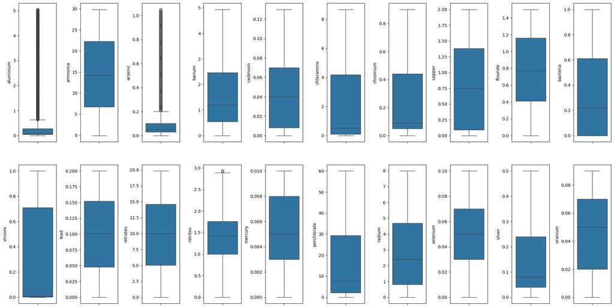

```python
#box plot distribution for features
fig, ax = plt.subplots(ncols=10, nrows=2, figsize=(20,10))
count = 0
ax = ax.flatten()
for i, value in X_train.items():
    sns.boxplot(y=i, data=X_train, ax=ax[count])
    count += 1
plt.tight_layout(pad=0.5, w_pad=0.7, h_pad=5.0)
```

```python
# create an instance
iso_model =  IsolationForest(n_estimators=500, max_samples = 0.8, max_features= 0.8, contamination = 0.05, bootstrap=True)

# train isolation forest model
iso_model.fit(X_train)

# predict train outliers
outlier_labels = iso_model.predict(X_train)

# Inlier training dataset
X_train_i = X_train[outlier_labels==1] ## inlier training feature set
Y_train_i = Y_train[outlier_labels==1] ## inlier training target set

# Inlier test dataset
X_test_i =X_test[iso_model.predict(X_test)==1] ## inlier test feature set
Y_test_i =Y_test[iso_model.predict(X_test)==1] ## inlier test target set

# Number of outliers detected and removed in training data
print('Number of outliers removed in training data:',len(X_train[outlier_labels==-1]))
```

```
Number of outliers removed in training data: 320
```

```python
# Print shape
print(f'Original X_train shape: {X_train.shape}')
print(f'Original Y_train shape: {Y_train.shape}')
print()
print(f'X_train shape after outlier removal: {X_train_i.shape}')
print(f'Y_train shape after outlier removal: {Y_train_i.shape}')
print()
print(f'Original X_test shape: {X_test.shape}')
print(f'Original Y_test shape: {Y_test.shape}')
print()
print(f'X_test shape after outlier removal: {X_test_i.shape}')
print(f'Y_test shape after outlier removal: {Y_test_i.shape}')
```

```
Original X_train shape: (6396, 20)
Original Y_train shape: (6396,)

X_train shape after outlier removal: (6076, 20)
Y_train shape after outlier removal: (6076,)

Original X_test shape: (1600, 20)
Original Y_test shape: (1600,)

X_test shape after outlier removal: (1485, 20)
Y_test shape after outlier removal: (1485,)
```

#### Building the pipeline

**Scaling**: We are using the StandardScaler to standardize our dataset. Standardization helps ensure that each feature contributes equally to the analysis, improving the performance of subsequent models, especially those sensitive to feature scaling.

**Feature Selection**: We have used ANOVA F-statistic scores and Mutual Information (MI) scores for feature selection to understand the association between features and the target variable. A large F-score with a small p-value indicates a strong linear relationship and statistical significance, suggesting that the feature is likely important for prediction. A large MI score complements this by capturing the non-linear dependencies. This combination helps ensure that selected features are both statistically significant and informative.

**Feature Reduction**: We are using Principal Component Analysis (PCA) to reduce the features in our dataset while retaining 90% of the variance. This method is particularly beneficial because it helps eliminate redundant and collinear features, simplifying the model without losing critical information. By focusing on the most significant components, we can improve the model performance.

```python
# Custom Transformer for Feature Selection
class FeatureSelector(BaseEstimator, TransformerMixin):
    def __init__(self, f_threshold=0.2, p_threshold=0.001, mi_threshold=0.2):
        self.f_threshold = f_threshold
        self.p_threshold = p_threshold
        self.mi_threshold = mi_threshold

    def fit(self, X, y):
        f, p = f_classif(X, y)
        f /= np.max(f)
        self.mi = mutual_info_classif(X, y)
        self.mi /= np.max(self.mi)

        # visualizing threshold for f score
        plt.figure()
        plt.plot(f, 'o')
        plt.plot(0.2*np.ones(len(f)))
        plt.ylabel('f score')
        plt.xlabel('features')

        # visualizing threshold for mi score
        plt.figure()
        plt.plot(self.mi, 'o')
        plt.plot(0.2*np.ones(len(self.mi)))
        plt.ylabel('mi score')
        plt.xlabel('features')

        # create mask
        self.feature_mask = ((f > self.f_threshold) & (p < self.p_threshold)) | (self.mi > self.mi_threshold)
        return self

    def transform(self, X):
        return X[:, self.feature_mask]
```

#### Best Preprocessing Sequence

The preprocessing steps we have chosen are as follows-

1. Outlier Detection using Isolation Forest (Implemented outside the pipeline for simplicity) --> 2. Scaling using Standard Scaler --> 3. Feature Selection using ANOVA F-statistic scores and Mutual Information (MI) scores --> 4. Feature Reduction using PCA

We believe this is the best set of sequence because -

By detecting and removing outliers before scaling, we prevent extreme values from skewing the scaling process, which could disproportionately affect the mean and standard deviation. Scaling is necessary before PCA, as PCA is sensitive to feature scaling. Features with larger magnitudes would dominate the principal components if left unscaled. Implementing feature selection next allows us to retain only the most relevant features based on their relationship with the target variable, which streamlines the dataset for more efficient processing. Feature reduction through PCA is done last, as it helps us reduce dimensionality while retaining the most important variations in the dataset only after the dataset has been cleaned and normalized. These steps should increase the likelihood of enhancing our models' generalization performance.

```python
# Constructing the pipeline
pipeline = Pipeline([
    ('scaling', StandardScaler()),
    ('feature_selection', FeatureSelector(f_threshold=0.2, p_threshold=0.001, mi_threshold=0.2)),
    ('pca', PCA(n_components=0.90))
])
```

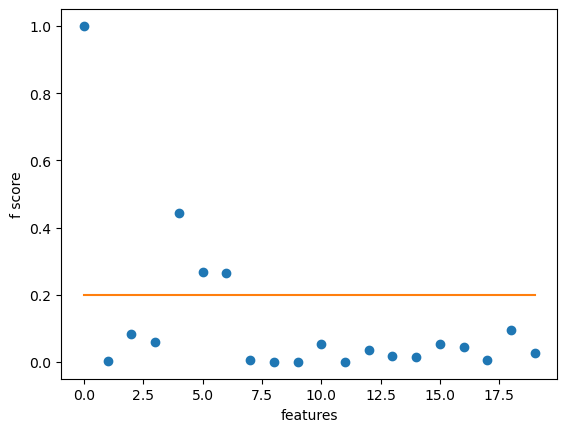

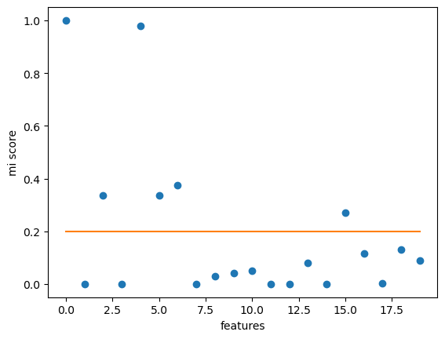

```python
# Fitting the pipeline on the training data
X_train_final = pipeline.fit_transform(X_train_i, Y_train_i)

# Applying the pipeline to the test data (without fitting again)
X_test_final = pipeline.transform(X_test_i)
```

```python
# Display shapes of the processed datasets
print(f'Final X_train shape: {X_train_final.shape}')
print(f'Final X_test shape: {X_test_final.shape}')

print(f'\nFinal Y_train shape: {Y_train_i.shape}')
print(f'Final Y_test shape: {Y_test_i.shape}')
```

```
Final X_train shape: (6076, 5)
Final X_test shape: (1485, 5)

Final Y_train shape: (6076,)
Final Y_test shape: (1485,)
```

# 3. Model Training and Testing

## 3.1 Hyperparameter Optimization using Optuna

The 5 models we used are - SVC, Random Forest, Decision tree, Logistic Regression, and KNN

```python
def objective_svc(trial):
    # Define the search space for hyperparameters
    C = trial.suggest_loguniform('C', 0.1, 10.0)
    gamma = trial.suggest_loguniform('gamma', 0.001, 1.0)
    kernel = trial.suggest_categorical('kernel', ['linear', 'rbf'])
    model = SVC(C=C, gamma=gamma, kernel=kernel, probability=True)
    model.fit(X_train_final, Y_train_i)
    Y_pred = model.predict(X_test_final)
    return accuracy_score(Y_test_i, Y_pred)

def objective_rf(trial):
    # Define the search space for hyperparameters
    n_estimators = trial.suggest_int('n_estimators', 50, 200)
    max_depth = trial.suggest_int('max_depth', 5, 50)
    min_samples_split = trial.suggest_int('min_samples_split', 2, 10)
    min_samples_leaf = trial.suggest_int('min_samples_leaf', 1, 5)

    model = RandomForestClassifier(
        n_estimators=n_estimators,
        max_depth=max_depth,
        min_samples_split=min_samples_split,
        min_samples_leaf=min_samples_leaf
    )
    model.fit(X_train_final, Y_train_i)
    Y_pred = model.predict(X_test_final)
    return accuracy_score(Y_test_i, Y_pred)

def objective_dt(trial):
    # Define the search space for hyperparameters
    criterion = trial.suggest_categorical('criterion', ['gini', 'entropy'])
    max_depth = trial.suggest_int('max_depth', 1, 20)
    min_samples_split = trial.suggest_int('min_samples_split', 2, 10)
    min_samples_leaf = trial.suggest_int('min_samples_leaf', 1, 5)
    model = DecisionTreeClassifier(
        criterion=criterion,
        max_depth=max_depth,
        min_samples_split=min_samples_split,
        min_samples_leaf=min_samples_leaf
    )
    model.fit(X_train_final, Y_train_i)
    Y_pred = model.predict(X_test_final)
    return accuracy_score(Y_test_i, Y_pred)

def objective_lr(trial):
    # Define the search space for hyperparameters
    C = trial.suggest_loguniform('C', 0.01, 10.0)
    model = LogisticRegression(C=C)
    model.fit(X_train_final, Y_train_i)
    Y_pred = model.predict(X_test_final)
    return accuracy_score(Y_test_i, Y_pred)

def objective_knn(trial):
    # Define the search space for hyperparameters
    n_neighbors = trial.suggest_int('n_neighbors', 3, 20)
    weights = trial.suggest_categorical('weights', ['uniform', 'distance'])
    model = KNeighborsClassifier(n_neighbors=n_neighbors, weights=weights)
    model.fit(X_train_final, Y_train_i)
    Y_pred = model.predict(X_test_final)
    return accuracy_score(Y_test_i, Y_pred)
```

```python
# Create a function to optimize models and store results
def optimize_and_store_results():
    results = {}

    # SVC Study
    svc_study = optuna.create_study(direction='maximize')
    svc_study.optimize(objective_svc, n_trials=100)
    results['SVC'] = {
        'best_params': svc_study.best_params,
        'best_accuracy': svc_study.best_value
    }

    # Random Forest Study
    rf_study = optuna.create_study(direction='maximize')
    rf_study.optimize(objective_rf, n_trials=100)
    results['Random Forest'] = {
        'best_params': rf_study.best_params,
        'best_accuracy': rf_study.best_value
    }

    # Decision Tree Study
    dt_study = optuna.create_study(direction='maximize')
    dt_study.optimize(objective_dt, n_trials=100)
    results['Decision Tree'] = {
        'best_params': dt_study.best_params,
        'best_accuracy': dt_study.best_value
    }

    # Logistic Regression Study
    lr_study = optuna.create_study(direction='maximize')
    lr_study.optimize(objective_lr, n_trials=100)
    results['Logistic Regression'] = {
        'best_params': lr_study.best_params,
        'best_accuracy': lr_study.best_value
    }

    # KNN Study
    knn_study = optuna.create_study(direction='maximize')
    knn_study.optimize(objective_knn, n_trials=100)
    results['KNN'] = {
        'best_params': knn_study.best_params,
        'best_accuracy': knn_study.best_value
    }

    return results

# Run optimization and get results
results = optimize_and_store_results()
```

[output not shown]

[output cut: 479 more lines]

```python
# Print results
print("\nOptimized Model Results:\n" + "="*30)
for model_name, result in results.items():
    print(f"{model_name}:")
    print("  Best Parameters:")
    for param, value in result['best_params'].items():
        print(f"    {param}: {value}")
    print("-" * 30)
```

```
Optimized Model Results:
==============================
SVC:
  Best Parameters:
    C: 8.75844600721275
    gamma: 0.18379714570173109
    kernel: rbf
------------------------------
Random Forest:
  Best Parameters:
    n_estimators: 162
    max_depth: 46
    min_samples_split: 9
    min_samples_leaf: 4
------------------------------
Decision Tree:
  Best Parameters:
    criterion: entropy
    max_depth: 6
    min_samples_split: 6
    min_samples_leaf: 2
------------------------------
Logistic Regression:
  Best Parameters:
    C: 0.06719114698675925
------------------------------
KNN:
  Best Parameters:
    n_neighbors: 14
    weights: uniform
------------------------------
```